# Efficient habits in Stata

Econometrics (ECN402) at the Norwegian School of Economics

Eirik Berger, Department of Economics

Spring 2020

# How to use Stata efficiently

## 1. How to start your dofile

Always begin you dofile in the same way (just copy and paste from old dofiles): 1) some basic information, 2) packages necessary to run the code, 3) preliminary settings, and 4) import the file structure. Example:

```stata
/*******************************************************************************
********************************************************************************

                     Lab 1 for Econometrics class

                         Written by Eirik Berger
                           PhD Research Scholar
                  The Norwegian School of Economics (NHH)

********************************************************************************
*******************************************************************************/

* Extra packages used (uncheck if not already installed)
* ssc install carryforward
* ssc install egenmore
* ssc install jarowinkler
* ssc install fs
* ssc install matchit
* ssc install winsor

* Preliminary settings
clear all
set matsize 1600
set scheme s1color
set more off

********************************************************************************
********************************************************************************

* Top folder for the project
global top "/Users/eirikberger/Dropbox/0_AKADEMISK/department_work/ECN402_spring_2020/lab0"

* Other globals: Based on global wd
global data "$top/data"
global dofiles  "$top/dofiles"
global figures  "$top/figures"
global tables  "$top/tables"

cd "$top"

/*******************************************************************************
********************************************************************************
********************************************************************************
********************************************************************************

 PART 1:
 XXXXXXX

********************************************************************************
********************************************************************************
********************************************************************************
*******************************************************************************/
```

## 2. Load and check your data

Always add “clear” as an option when you open a .dta file. Also, don’t include the full path: It is cleaner to either use globals (see below) or use the “cd” (change directory) command.

```stata
use "$data/BWGHT.DTA", clear
list faminc cigtax cigprice in 1/10, noobs
```

```
  | faminc   cigtax   cigprice |
  |----------------------------|
  |   13.5     16.5      122.3 |
  |    7.5     16.5      122.3 |
  |     .5     16.5      122.3 |
  |   15.5     16.5      122.3 |
  |   27.5     16.5      122.3 |
  |----------------------------|
  |    7.5     16.5      122.3 |
  |     65     16.5      122.3 |
  |   27.5     16.5      122.3 |
  |   27.5     16.5      122.3 |
  |   37.5     16.5      122.3 |
  +----------------------------+
```

```stata
sum faminc
```

```
    Variable |        Obs        Mean    Std. Dev.       Min        Max
-------------+---------------------------------------------------------
      faminc |      1,388    29.02666    18.73928         .5         65
```

Or simply use the “browse” command (“br” for short) to look at your dataset directly.

## 3. How to re-use results (using locals)

Sometimes we want to save certain numbers coming from Stata commands for later use. Example: What is the share of white mothers who smoke? First, we find the number of white mothers.

```stata
count if white==1
```

```
  1,089
```

Then the number of white mothers who smoke.

```stata
count if white==1 & cigs>0
```

```
  165
```

I copy the answers from the above commands and calculate the answer using the “display” command. Note that the display command functions as a calculator when you don’t use “”.

```stata
display 165/1089
```

```
.15151515
```

However, we can do this without any manual copy-and-paste work. Using the “return list” command after running the “count” command, we find that the count command returns (saves) the scalar “r(N)”.

```stata
count if white==1
```

```
  1,089
```

```stata
return list
```

```
scalars:
                  r(N) =  1089
```

Similarly for the “sum” command:

```stata
sum cigs
```

```
    Variable |        Obs        Mean    Std. Dev.       Min        Max
-------------+---------------------------------------------------------
        cigs |      1,388    2.087176    5.972688          0         50
```

```stata
return list
```

```
scalars:
                  r(N) =  1388
              r(sum_w) =  1388
               r(mean) =  2.087175792507205
                r(Var) =  35.67300052567169
                 r(sd) =  5.972687881152981
                r(min) =  0
                r(max) =  50
                r(sum) =  2897
```

We use the “local” command to save the mean (r(mean)) as “groupmean”. You can check the content of “groupmean” by using the display command.

```stata
local groupmean = r(mean)
display "`groupmean'"
```

```
2.087175792507205
```

Put it all together and we can estimate the share of smokers among white mother in one go:

```stata
count if white==1
local white = r(N)
display "Saved number is: " `white'
count if white==1 & cigs>0
local whiteandsmoke = r(N)
display "Saved number is :"`whiteandsmoke'
display "The fraction of white people that smoke is: " `whiteandsmoke'/`white'
display "or in percent " 100*(`whiteandsmoke'/`white') "%"
```

```
  1,089


Saved number is: 1089

  165


Saved number is :165

The fraction of white people that smoke is: .15151515

or in percent 15.151515%
```

## 4. Using global to deal with folder structures

Globals are a great way of keeping your dofile clear and the file structure organized. With globals you save a string (text) to a name, like at the beginning of my dofile. Use $[name] to retrieve it. In the following example, I save the path to my working directory and then change the directory:

```stata
global wd "/Users/eirikberger/Dropbox/0_AKADEMISK/department_work/ECN402_spring_2020/lab0"
cd "$wd"
```

Similarly, to open a dataset in the data folder (already saved as a global), you write:

```stata
use "$data/BWGHT.DTA", clear
```

## 5. Comment a lot!

Use “*" to write comments in your dofile. This symbol can also be used to “turn off” a command by placing “*" in front of the command to save it for later. Use “//” if you want to comment on the same line as a command (see example below). You can also create a full section with text only (parts that are not interpreted as code), by writing “/*" to start the section and “*/" to end it (see point no. 1 for an example).

It’s challenging to interpret code for future you or co-authors. Note: You have to hand in your dofile for assignments (as an appendix in your main pdf file). The dofile should 1) reproduce your results, 2) it should be clear what you have done (use comments) and 3) it should look tidy and nice.

## 6. Logs

You have to hand in the log from running your full dofile (as an appendix in your main pdf file). It might be easiest to add the commands below when you create your dofile, but to make them inactive (use “*" in front of them) until you are done and run the full dofile in one go.

```stata
capture log close           // Could add this to your preliminaries. Closes the log file given that a log files is recording
log using introlab, text replace            // Opens a log and saves it as a text file.
capture log close          // close and saves the log file given that a log file is recording
exit         // Useful closing commands
```

Note that you might find the “capture” command useful at some point, especially when your dofile has to be able to deal with several different datasets. It executes the command following it (same line), given that there are no errors. If there are any errors in the following command, it stops the process and continues with the next line. Examples, where this might be useful, is to drop a certain variable given that it exists. For example, if you might have a bwght variable and an income variable, but it is not certain:

```stata
drop bwght
```

This command works because there is indeed a variable named bwght. What about income:

```stata
drop income
```

We get an error because there is no such variable. To run the code without any error, we run:

```stata
capture drop income
```

## 7. Use Google and the “help” command

Just do it. Ask for help if you can’t find it there.

## 8. Delimit

In cases where one command goes across several lines (for example when you are producing figures), you can use #delimit ; and #delimit cr. Example

```stata
#delimit ;
esttab lin_all lin_high using A1_tab1.tex,
  b(%4.2f) se(%4.2f) r2(%4.2f) scalars(Prediction) replace label star(* 0.10 ** 0.05 *** 0.01)
  mtitles("All countries" "High-income countries")
  title("Linear regression model: Outcome is labour productivity in agriculture");
#delimit cr
```

Remember to add the “;” at the end of the last line in the command.

## 9. Logical statements

Remember the logical statments:

- & and
- | or
- != not equal to
- == equal to
- > larger than
- < smaller than
- => larger or equal to
- =< smaller than or equal to

# From last lecture

Vincent asked me to go through how you run an f-test in Stata. I think this is an excellent opportunity to learn how to figure out these kinds of questions by yourself.

## 1. T-test

If you search for “t-test” on google, you will find this page quite soon (the stata help manual for the command “ttest”): https://www.stata.com/manuals13/rttest.pdf. It gives you all the information you need about the syntax of the command + good examples of how to use the command.

## 2. F-test

How should we learn to use the f-test? You guessed it: Just use the same trick as for the t-test and find this help page (the stata help manual for the command “test”): https://www.stata.com/manuals13/rtest.pdf

```stata
reg faminc cigtax cigprice bwght male white
```

```
      Source |       SS           df       MS      Number of obs   =     1,388
-------------+----------------------------------   F(5, 1382)      =     40.07
       Model |  61667.9131         5  12333.5826   Prob > F        =    0.0000
    Residual |  425392.101     1,382  307.809045   R-squared       =    0.1266
-------------+----------------------------------   Adj R-squared   =    0.1235
       Total |  487060.014     1,387  351.160789   Root MSE        =    17.544

------------------------------------------------------------------------------
      faminc |      Coef.   Std. Err.      t    P>|t|     [95% Conf. Interval]
-------------+----------------------------------------------------------------
      cigtax |  -.7546118   .1254443    -6.02   0.000    -1.000694     -.50853
    cigprice |   .6144594   .0953262     6.45   0.000     .4274597    .8014591
       bwght |   .0674765   .0234134     2.88   0.004     .0215469     .113406
        male |  -1.750652   .9463898    -1.85   0.065    -3.607168    .1058639
       white |   13.45813   1.163566    11.57   0.000     11.17558    15.74067
       _cons |   -54.0982   10.69192    -5.06   0.000    -75.07234   -33.12405
------------------------------------------------------------------------------
```

To use the f-test to test the joint null hypothesis that the coefficients on both “cigtax” and “cigprice” are equal to zero, we use the “test” command. It’s really intuitive:

```stata
test (cigtax = 0) (cigprice = 0)
```

```
 ( 1)  cigtax = 0
 ( 2)  cigprice = 0

       F(  2,  1382) =   21.08
            Prob > F =    0.0000
```

Or with even less code:

```stata
test cigtax cigprice
```

```
 ( 1)  cigtax = 0
 ( 2)  cigprice = 0

       F(  2,  1382) =   21.08
            Prob > F =    0.0000
```

What about testing if they are equal to each other?

```stata
test cigtax = cigprice
```

```
 ( 1)  cigtax - cigprice = 0

       F(  1,  1382) =   40.99
            Prob > F =    0.0000
```

# Assignment 1

You should always attempt to fully automate the production of your output, as this will save you a lot of time if you have to do lots of revisions. Note: With LaTex (Word for academia), you can go even further in making your workflow efficient. You might be okay with less efficiency in this course, but it could save you days of work when writing an empirical master and PhD thesis.

## 1. Produce and export regression results

Based on the hint dofile of assignment 1:

```stata
* Install estout (place "*" in front of ssc... once installed)
ssc install estout
```

Run 2 regression and save the estimated coefficients.

```stata
reg bwght cigs
estimates store reg1
```

```
      Source |       SS           df       MS      Number of obs   =     1,388
-------------+----------------------------------   F(1, 1386)      =     32.24
       Model |  13060.4194         1  13060.4194   Prob > F        =    0.0000
    Residual |    561551.3     1,386  405.159668   R-squared       =    0.0227
-------------+----------------------------------   Adj R-squared   =    0.0220
       Total |   574611.72     1,387  414.283864   Root MSE        =    20.129

------------------------------------------------------------------------------
       bwght |      Coef.   Std. Err.      t    P>|t|     [95% Conf. Interval]
-------------+----------------------------------------------------------------
        cigs |  -.5137721   .0904909    -5.68   0.000    -.6912861   -.3362581
       _cons |   119.7719   .5723407   209.27   0.000     118.6492    120.8946
------------------------------------------------------------------------------
```

```stata
reg bwght cigs white
estimates store reg2
```

```
      Source |       SS           df       MS      Number of obs   =     1,388
-------------+----------------------------------   F(2, 1385)      =     27.47
       Model |  21925.2578         2  10962.6289   Prob > F        =    0.0000
    Residual |  552686.462     1,385  399.051597   R-squared       =    0.0382
-------------+----------------------------------   Adj R-squared   =    0.0368
       Total |   574611.72     1,387  414.283864   Root MSE        =    19.976

------------------------------------------------------------------------------
       bwght |      Coef.   Std. Err.      t    P>|t|     [95% Conf. Interval]
-------------+----------------------------------------------------------------
        cigs |  -.5059517   .0898216    -5.63   0.000    -.6821527   -.3297507
       white |   6.148295   1.304469     4.71   0.000     3.589346    8.707244
       _cons |   114.9317   1.173547    97.94   0.000     112.6296    117.2339
------------------------------------------------------------------------------
```

Make a table with results from reg1 and reg2. Lots of opportunities to make the regression table nicer!

```stata
esttab reg1 reg2, title("Joint regression table:")
```

```
Joint regression table:
--------------------------------------------
                      (1)             (2)
                    bwght           bwght
--------------------------------------------
cigs               -0.514***       -0.506***
                  (-5.68)         (-5.63)

white                               6.148***
                                   (4.71)

_cons               119.8***        114.9***
                 (209.27)         (97.94)
--------------------------------------------
N                    1388            1388
--------------------------------------------
t statistics in parentheses
* p<0.05, ** p<0.01, *** p<0.001
```

Use “help esttab” or google if you want to customize your regression results. For example, you can use “estadd scalar” to add a number to your table.

## 2. Produce and export figures

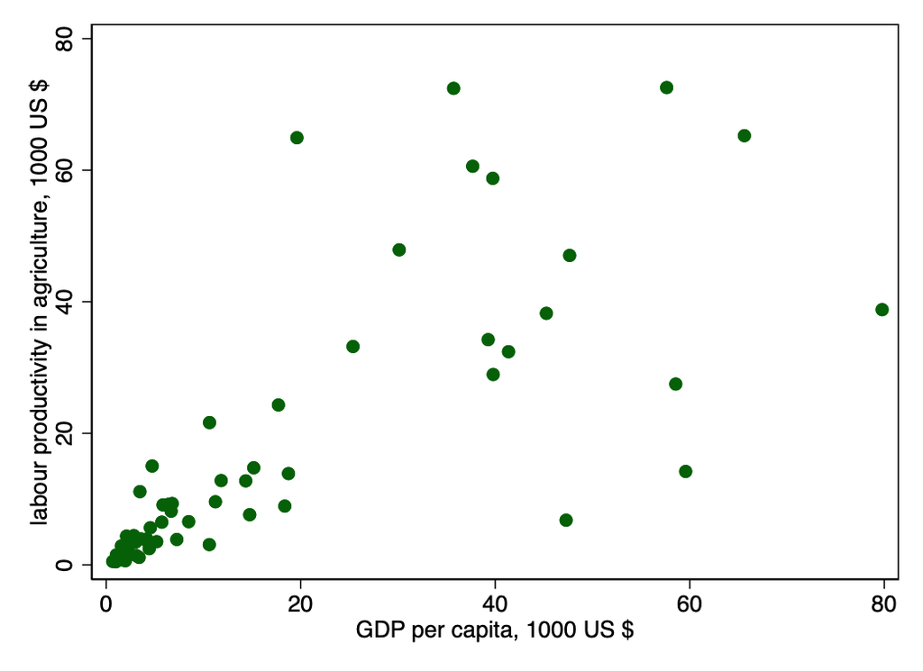

```stata
graph twoway scatter LP_agric gdpcapita, name(LP, replace)
graph export "$figures/graph_1.png", replace
```

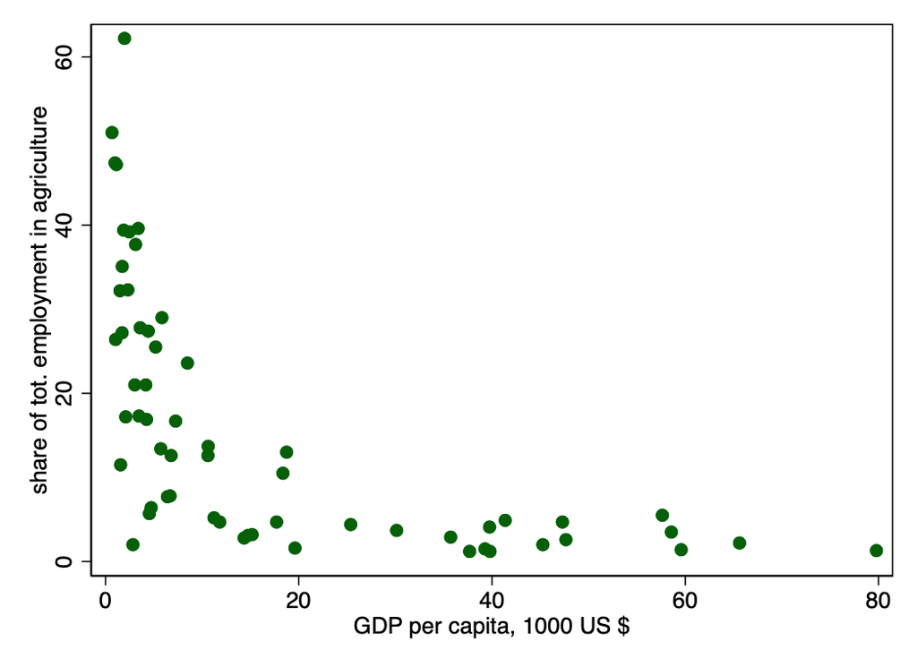

```stata
graph twoway scatter share_empl_agric gdpcapita, name(empshare, replace)
graph export "$figures/graph_2.png", replace
```

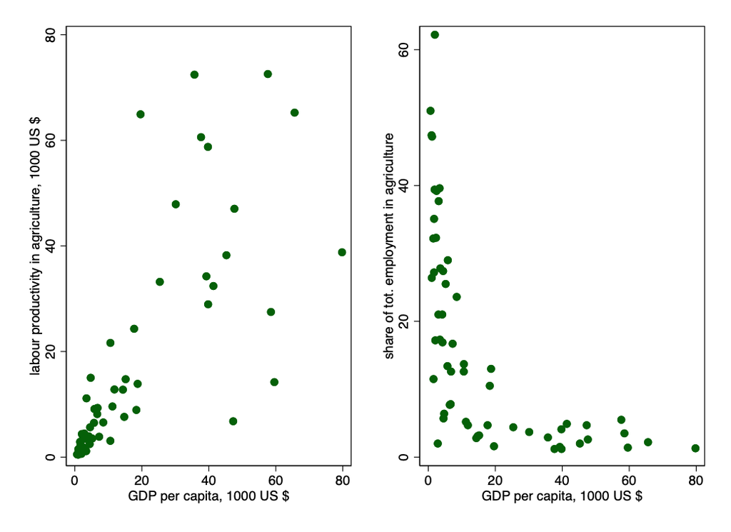

```stata
graph combine LP empshare, cols(2)
graph export "$figures/scatterGDP.png", replace
```